# From Insight to Action

Author

jl3205

> *“Where digital systems were in place, humanitarian actors gained a decisive edge in crisis response — improving targeting of assistance, coordination across agencies, and adaptive response planning.”*<sup>1</sup>

## Call to Action

Data alone cannot protect frontline workers. But when structured, analyzed, and acted upon, it can sharpen our collective foresight, giving us the ability to see into the future and help prevent devastating attacks before they occur.

## Future Actions & Intelligence Roadmap

These future actions are made by building on past patterns. This roadmap outlines a practical intelligence roadmap by transforming analysis into actionable protection.

- **Operational Sandbox**:
  - Create an open-data dashboard for NGOs to explore historical incidents, identify emerging clusters, and anticipate future threats.
  - *Inspired by EDA findings showing persistent spatial and thematic clusters.*
- **Real-Time Risk Scoring**:
  - Use logistic models trained on incident features to evaluate new reports and estimate fatality likelihood in real time. Built on the logistic regression performance shown in this project.
- **Geo-Temporal Intelligence Fusion**: Integrate field data with external streams (e.g., satellite, SMS alerts, social media signals). insiprireed from my animated timeline an dthreat hotspot mapping

## Humanitarian Threat Anticipation System

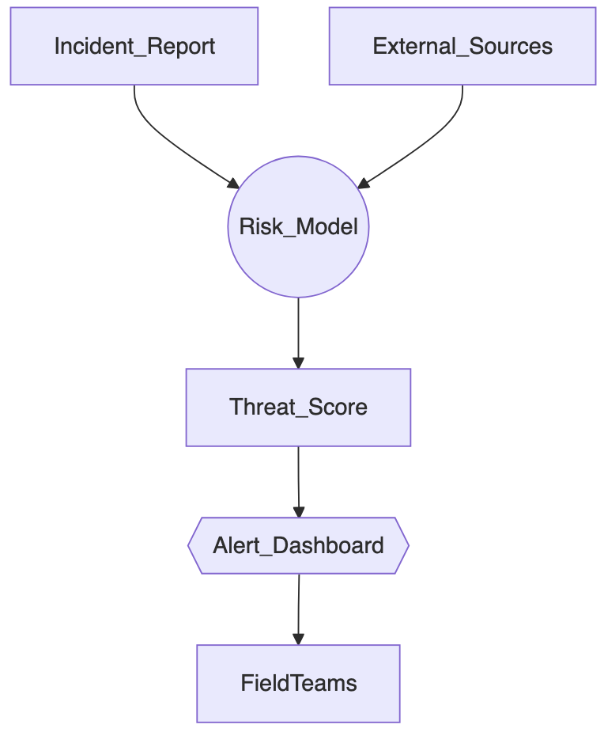

> **Note:**

> incident logs + external intel → model → alert → field action.

## References

1.

KuRpiewsKa-KoRbut, R. Digital technologies in the global humanitarian sector: A case study of ukraine. *Journal of Modern Science* **60**, 730–743 (2024).